# Solutions 16: Error Assumptions

### Check the constant error variance assumption.

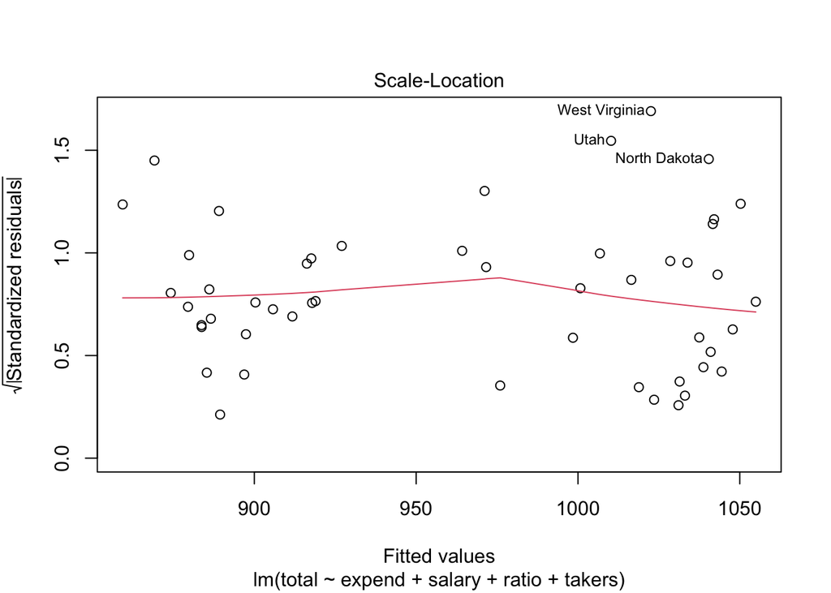

```r
# More resolution
plot(lmod3, which = 3)
```

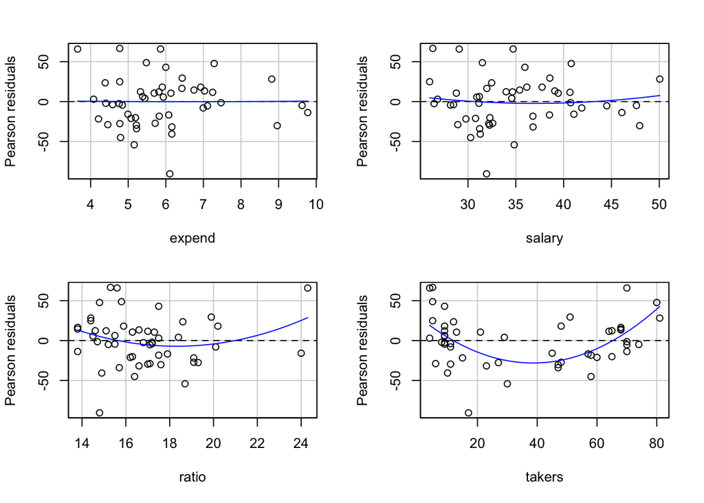

```r
# fitted values vs regressors
residualPlots(lmod3, fitted = FALSE, tests = FALSE, quadratic = TRUE)
```

- Nothing too alarming in the plots above. The residuals against takers plot probably looks the most problematic, but no clear indications of heteroscedasticity.
- Maybe a slight nonlinear, quadratic pattern with `takers`?

```r
# fit model add quadratic term
lmod4 <- lm(total ~ expend + salary + ratio + takers + I(takers^2), data = sat)
summary(lmod4)
```

```
Call:
lm(formula = total ~ expend + salary + ratio + takers + I(takers^2),
    data = sat)

Residuals:
    Min      1Q  Median      3Q     Max
-68.181 -15.460  -1.722  18.063  52.163

Coefficients:
              Estimate Std. Error t value Pr(>|t|)
(Intercept) 1014.42328   43.04498  23.567  < 2e-16 ***
expend         9.11166    8.54525   1.066    0.292
salary        -0.07770    1.95288  -0.040    0.968
ratio          2.13991    2.83171   0.756    0.454
takers        -6.70915    0.77820  -8.621 5.26e-11 ***
I(takers^2)    0.05183    0.01029   5.035 8.58e-06 ***
---
Signif. codes:  0 '***' 0.001 '**' 0.01 '*' 0.05 '.' 0.1 ' ' 1

Residual standard error: 26.34 on 44 degrees of freedom
Multiple R-squared:  0.8887,    Adjusted R-squared:  0.8761
F-statistic: 70.27 on 5 and 44 DF,  p-value: < 2.2e-16
```

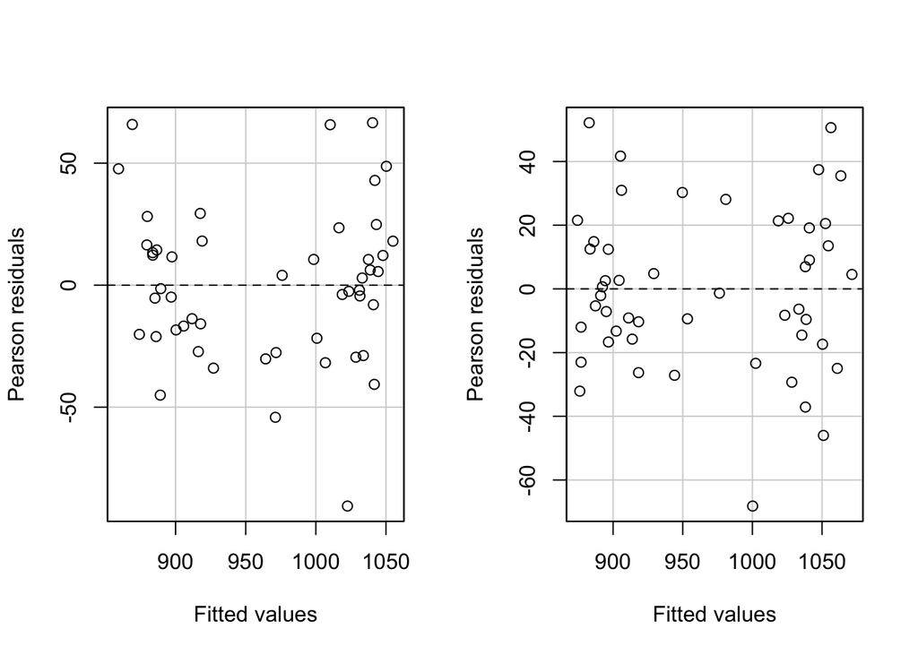

```r
# plot residuals vs fitted values.
par(mfrow = c(1, 2))
residualPlot(lmod3, quadratic = FALSE)
residualPlot(lmod4, quadratic = FALSE)
```

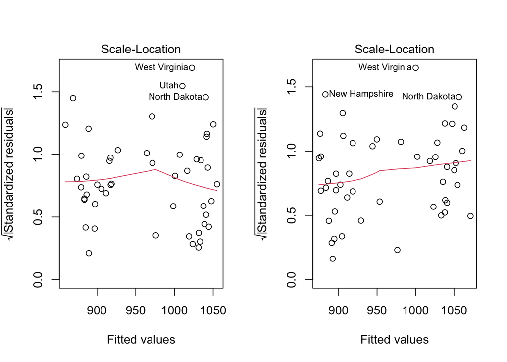

```r
par(mfrow = c(1, 2))
# More resolution
plot(lmod3, which = 3)
plot(lmod4, which = 3)
```

```r
par(mfrow = c(1, 1))
```

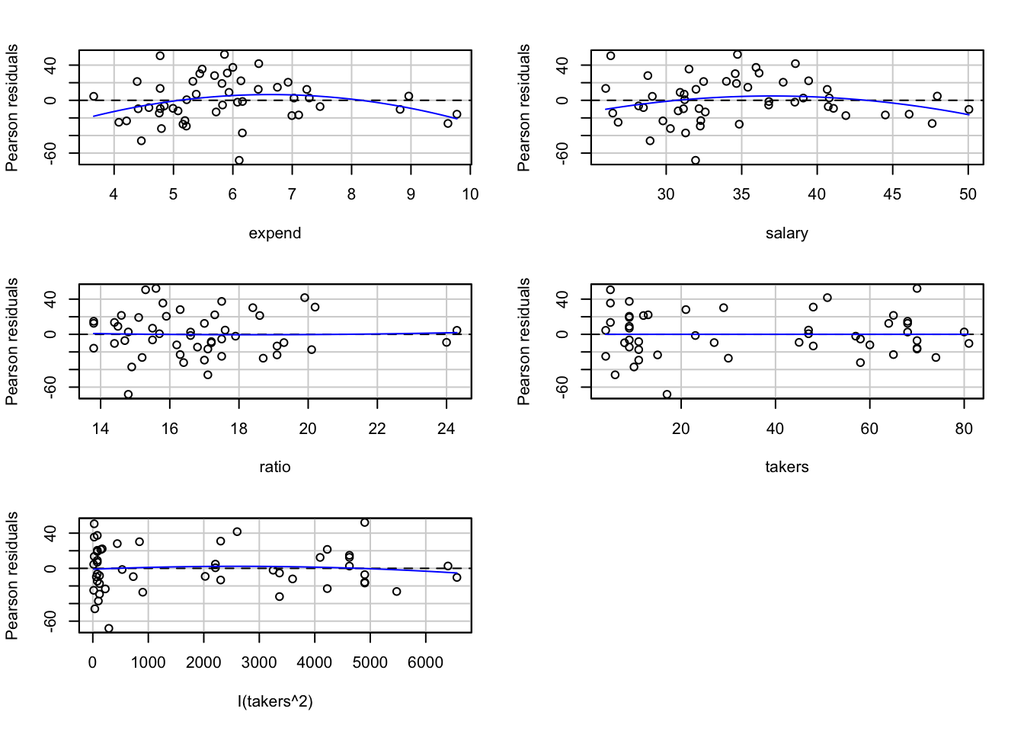

```r
# fitted values vs regressors
residualPlots(lmod4, fitted = FALSE, tests = FALSE, quadratic = TRUE)
```

- Did we fix the problem or cause more problems?

```r
# add more quadratic terms
lmod5 <- lm(total ~ expend + salary + ratio + takers + I(expend^2) + I(salary^2) + I(takers^2), data = sat)
summary(lmod5)
```

```
Call:
lm(formula = total ~ expend + salary + ratio + takers + I(expend^2) +
    I(salary^2) + I(takers^2), data = sat)

Residuals:
    Min      1Q  Median      3Q     Max
-71.796 -12.460  -2.027  16.389  53.583

Coefficients:
             Estimate Std. Error t value Pr(>|t|)
(Intercept) 806.98847  148.67786   5.428 2.63e-06 ***
expend       53.78381   29.60206   1.817   0.0764 .
salary        2.26868   10.00740   0.227   0.8218
ratio         4.27556    2.93584   1.456   0.1527
takers       -7.48056    0.84913  -8.810 4.28e-11 ***
I(expend^2)  -3.04065    2.11760  -1.436   0.1584
I(salary^2)  -0.04378    0.13680  -0.320   0.7505
I(takers^2)   0.06175    0.01112   5.552 1.75e-06 ***
---
Signif. codes:  0 '***' 0.001 '**' 0.01 '*' 0.05 '.' 0.1 ' ' 1

Residual standard error: 25.56 on 42 degrees of freedom
Multiple R-squared:    0.9, Adjusted R-squared:  0.8833
F-statistic: 53.98 on 7 and 42 DF,  p-value: < 2.2e-16
```

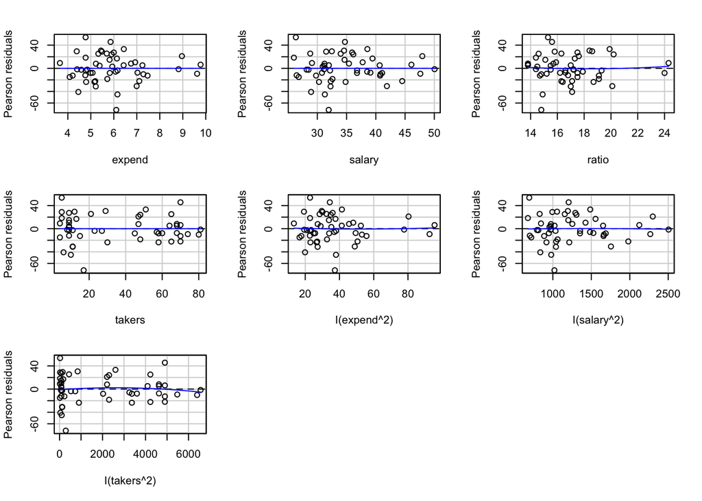

```r
# fitted values vs regressors
residualPlots(lmod5, fitted = FALSE, tests = FALSE, quadratic = TRUE)
```

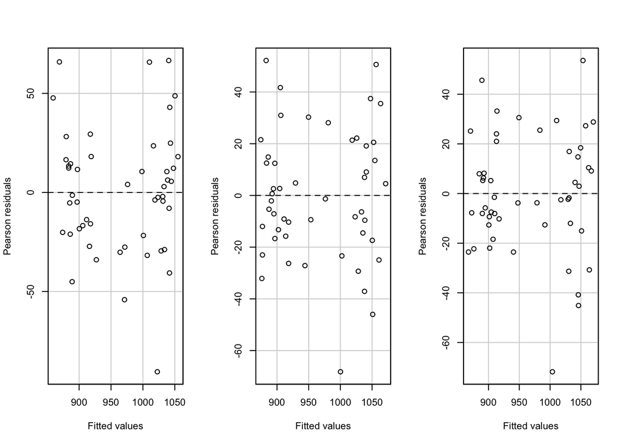

```r
# plot residuals vs fitted values.
par(mfrow = c(1, 3))
residualPlot(lmod3, quadratic = FALSE)
residualPlot(lmod4, quadratic = FALSE)
residualPlot(lmod5, quadratic = FALSE)
```

```r
par(mfrow = c(1, 1))
```

### Check the normal error assumption.

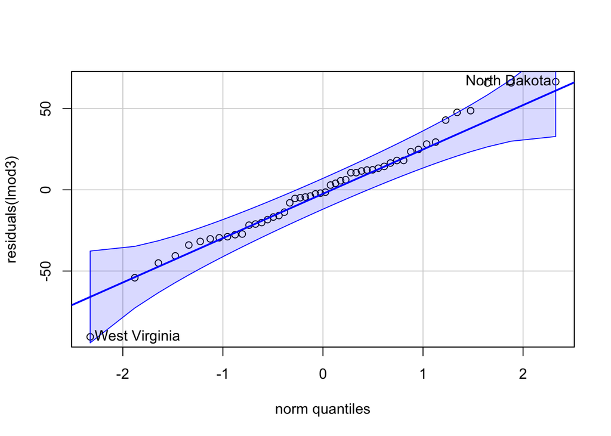

```
West Virginia  North Dakota
           48            34
```

```r
# check normality assumption
# no major evidence of a problem
qqPlot(residuals(lmod3))
```

- This assumption looks good too!

### Should we check for correlated errors?

- There are tons of possible patterns we could try to investigate, but we really have no reason to suspect any correlation in the errors.
- All of the data is from the same years (1994-1995), and we do not know which observations were taken at what time. So there is no temporal data.
- I suppose we do have some spatial data, such as state, so we could look for a pattern by region for example?

```r
 # 9 states is south
sat$region[row.names(sat) == "Alabama" | row.names(sat) == "Arkansas" | row.names(sat) == "Louisiana" | row.names(sat) == "Tennessee" | row.names(sat) == "North Carolina" | row.names(sat) =="South Carolina" | row.names(sat) == "Georgia" | row.names(sat) == "Florida" | row.names(sat) == "Mississippi"]  <- "South"

 # 13 states is northeast
sat$region[row.names(sat) == "Maine" | row.names(sat) == "Vermont" | row.names(sat) == "New Hampshire" | row.names(sat) == "Massachusetts" | row.names(sat) == "Connecticut" | row.names(sat) == "Rhode Island" | row.names(sat) == "New York" | row.names(sat) == "New Jersey" | row.names(sat) == "Pennsylvania" | row.names(sat) == "West Virginia" | row.names(sat) == "Virginia" | row.names(sat) == "Maryland" | row.names(sat) == "Delaware"]  <- "Northeast"

# 9 states in Midwest
sat$region[row.names(sat) == "Minnesota" | row.names(sat) == "Wisconsin" | row.names(sat) == "Illinois" | row.names(sat) == "Iowa" | row.names(sat) == "Missouri" | row.names(sat) == "Kentucky" | row.names(sat) == "Indiana" | row.names(sat) == "Ohio" | row.names(sat) == "Michigan"]  <- "Midwest"

# 10 states in plains
sat$region[row.names(sat) == "Montana" | row.names(sat) == "North Dakota" | row.names(sat) == "Wyoming" | row.names(sat) == "Colorado" | row.names(sat) == "New Mexico" | row.names(sat) == "Texas" | row.names(sat) == "Kansas" | row.names(sat) == "Nebraska" | row.names(sat) == "South Dakota" | row.names(sat) == "Oklahoma"]  <- "Plains"

# 9 States in Pacific
sat$region[row.names(sat) == "Washington" | row.names(sat) == "Oregon" | row.names(sat) == "Idaho" | row.names(sat) == "California" | row.names(sat) == "Nevada" | row.names(sat) == "Arizona" | row.names(sat) == "Utah" | row.names(sat) == "Alaska" | row.names(sat) == "Hawaii"]  <- "Pacific"
```

```r
sat$region <- factor(sat$region)
levels(sat$region)
```

```
[1] "Midwest"   "Northeast" "Pacific"   "Plains"    "South"
```

```r
lmod3_region <- lm(total ~ expend + salary + ratio + takers + region, data = sat)
```

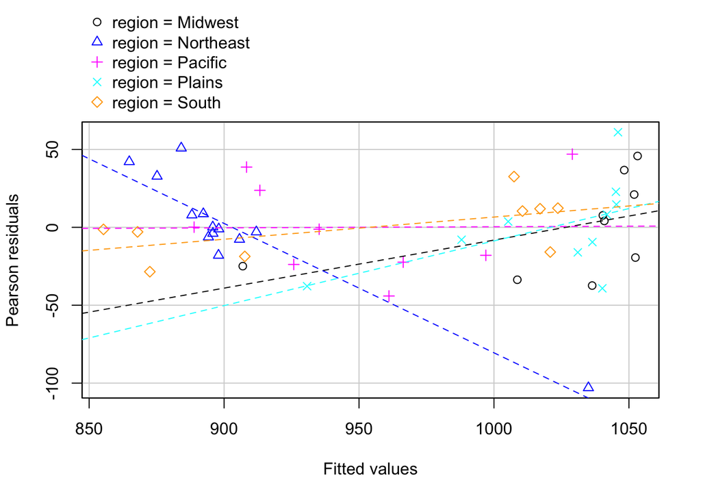

```r
# plot residuals vs fitted values.
residualPlot(lmod3_region, quadratic = FALSE , groups = "region")
```

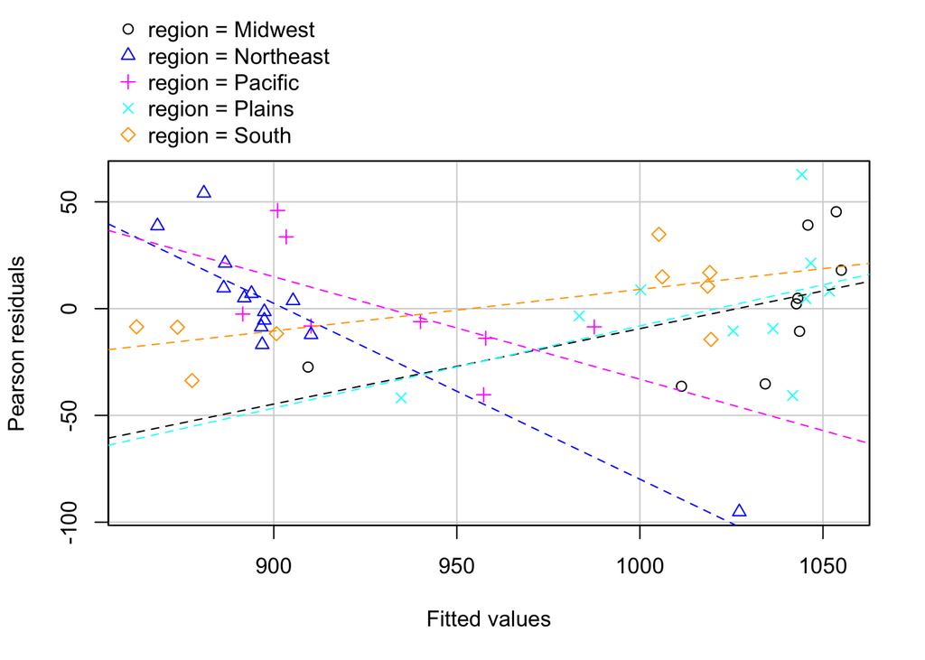

```r
# Remove Utah
sat <- sat[!(row.names(sat) %in% "Utah"), ]

lmod3_region2 <- lm(total ~ expend + salary + ratio + takers + region, data = sat)

# plot residuals vs fitted values.
residualPlot(lmod3_region2, quadratic = FALSE, groups = "region")
```

# Useful R Functions for Checking Error Assumptions

## Extracting Residuals

- `residuals(lmod)` extracts the OLS residuals.
- `rstandard(lmod)` extracts the standardized residuals.
- `rstudent(lmod)` extracts the studentized residuals.

## Mean-Zero Error Assumption

- `car::residualPlot` constructs a plot of the residuals versus fitted values.
- `plot(lmod, which = 1)` constructs a plot of the residuals versus fitted values.

## Constant Error Variance Assumption

- `car::residualPlots` constructs a plots of the residuals versus each predictor and the residuals versus the fitted values.
- `plot(lmod, which = 3)` constructs a plot of **square root of standardized residuals** versus the fitted values to increase resolution.

## Error Normality

- `car::qqPlot(lmod)` will produce a q-q plot for the **studentized residuals**, along with the appropriate t-based, pointwise confidence bands for what is expected if $\boldsymbol\epsilon \sim N(0, \sigma^2 I)$.
- `plot(lmod, which = 2)` will produce a q-q plot for the **standardized residuals**, along with a helpful reference line.
- `shapiro.test(residuals(lmod))` performs a Shapiro-Wilk test on the residuals.

## Correlated Errors

- `lmtest::dwtest` performs a Durbin-Watson test on the residuals of a fitted model

# Summary of Methods for Checking Error Assumptions

## Mean-Zero Error Assumption

- Plot of residuals versus fitted values

## Constant Error Variance Assumption

- Plot of residuals versus fitted values
- Plot of $\sqrt{| \hat{\epsilon} |}$ versus fitted values.
- Plot of standardized residuals versus fitted values.
- Plot of residuals versus each regressor.

## Normal error assumption

- Q-Q plot of residuals
- Shapiro-Wilk test

## Uncorrelated Errors

- Plot of residuals versus time
- Plot of successive pairs of residuals
- Durbin-Watson test